# The R Package clueR

Pengyi Yang & Steve Pederson

7 December 2015

## Reading data in R and exploratory data analysis

#### Read in a tab-delimited dataset from plain text file and calculate summary statistics

```r
Adipo.dat <- read.delim("data/Adipogenesis.txt", head=TRUE)
Adipo.dat[1:5,]
```

```
##   GeneSymbol    t0.5h      t1h      t2h       t4h        t8h       t48h
## 1      Nr4a1 4.139264 4.695290 4.557286 4.1127582  3.4080955  2.4537373
## 2        Fos 4.389225 4.093885 1.806750 1.2671636  0.8352796  0.5272506
## 3       Btg2 3.989989 3.995800 1.645890 0.7139266 -0.6195376 -0.4145120
## 4      Ptgs2 4.337712 5.460611 4.642035 3.0987586  1.3670011  0.7382098
## 5       Rgs2 2.822143 3.376263 3.523400 3.3030717  2.6106386  2.7989720
```

subsetting a matrix

```r
Adipo.exp <- as.matrix(Adipo.dat[,-1]) # removing the ID column from the raw data to create a numeric matrix containing the expression of the genes at each time point
rownames(Adipo.exp) <- Adipo.dat[,1] # assign the row names of the matrix as the ID in the first column
Adipo.exp[1:5,] # displaying the first five rows of the expression matrix
```

```
##          t0.5h      t1h      t2h       t4h        t8h       t48h
## Nr4a1 4.139264 4.695290 4.557286 4.1127582  3.4080955  2.4537373
## Fos   4.389225 4.093885 1.806750 1.2671636  0.8352796  0.5272506
## Btg2  3.989989 3.995800 1.645890 0.7139266 -0.6195376 -0.4145120
## Ptgs2 4.337712 5.460611 4.642035 3.0987586  1.3670011  0.7382098
## Rgs2  2.822143 3.376263 3.523400 3.3030717  2.6106386  2.7989720
```

```r
summary(Adipo.exp)
```

```
##      t0.5h                t1h                t2h
##  Min.   :-2.187384   Min.   :-1.90305   Min.   :-2.723784
##  1st Qu.:-0.051696   1st Qu.:-0.08715   1st Qu.:-0.123376
##  Median : 0.008043   Median :-0.01620   Median : 0.004174
##  Mean   : 0.010743   Mean   :-0.01216   Mean   :-0.003355
##  3rd Qu.: 0.070590   3rd Qu.: 0.05336   3rd Qu.: 0.106438
##  Max.   : 4.389225   Max.   : 5.46061   Max.   : 5.419228
##       t4h                 t8h                t48h
##  Min.   :-3.546043   Min.   :-4.57534   Min.   :-4.48677
##  1st Qu.:-0.143953   1st Qu.:-0.13082   1st Qu.:-0.11234
##  Median : 0.028906   Median : 0.07001   Median : 0.05885
##  Mean   : 0.003566   Mean   : 0.02734   Mean   : 0.02059
##  3rd Qu.: 0.154741   3rd Qu.: 0.21931   3rd Qu.: 0.19805
##  Max.   : 5.422899   Max.   : 5.22746   Max.   : 6.37389
```

Read data from R data object

```r
load("data/DEGs.RData") # This data contains differentially expressed genes
# subset the expression matrix to select only DE gene experssions
Adip.exp.DEGs <- Adipo.exp[DEGs,]
```

write table

```r
#write.table(Adip.exp.DEGs, file="Adipogenesis_DE.txt", quote=F, sep="\t")
#save(Adipo.dat, file="Adipo.RData")
```

#### Exploratory data analysis and visualisation

boxplot

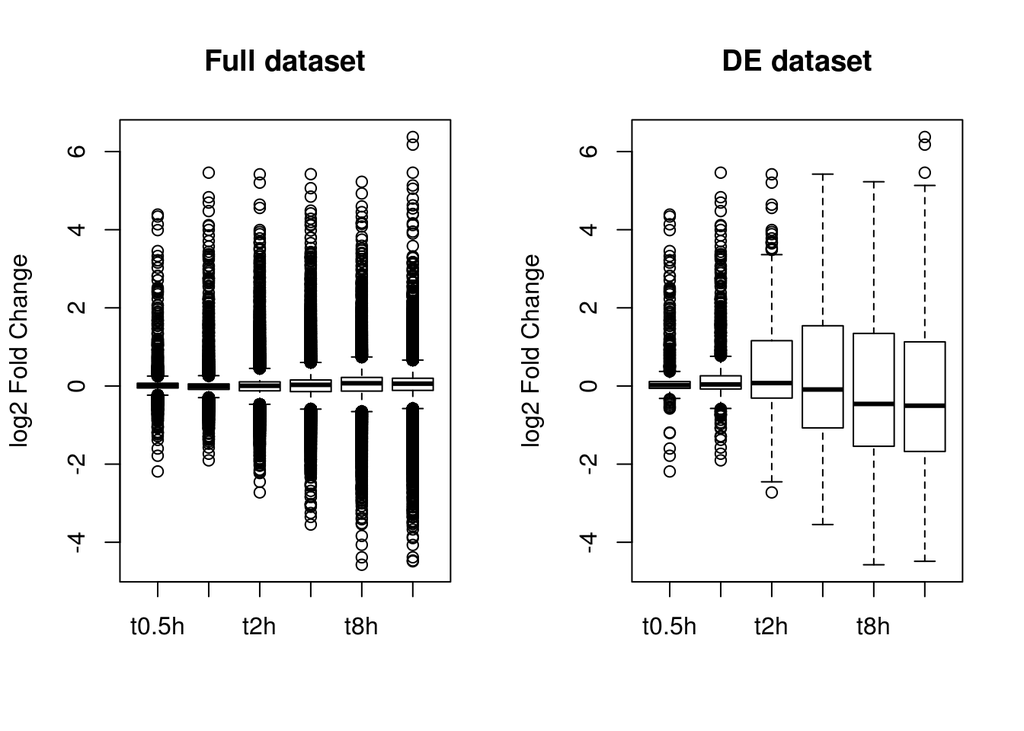

```r
par(mfrow=c(1, 2))
boxplot(Adipo.exp, ylab="log2 Fold Change", main="Full dataset")
boxplot(Adip.exp.DEGs, ylab="log2 Fold Change", main="DE dataset")
```

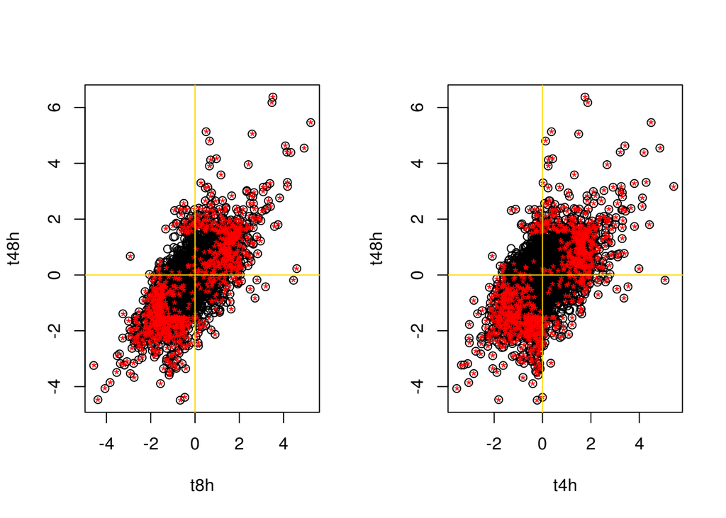

```r
par(mfrow=c(1, 2))
# Scatter plot the full data and highlight the DE genes in the scatter plot
plot(Adipo.exp[,c("t8h", "t48h")])
points(Adipo.exp[DEGs,c("t8h", "t48h")], pch="*", col="red", main="8h vs 48h")
abline(h=0, v=0, col="gold")
# generating pairwise correlation plots
plot(Adipo.exp[,c("t4h", "t48h")])
points(Adipo.exp[DEGs,c("t4h", "t48h")], pch="*", col="red", main="4h vs 48h")
abline(h=0, v=0, col="gold")
```

## Install package and calling functions from packages

Install an R package called ‘corrplot’ from CRAN (The Comprehensive R Archive Network)

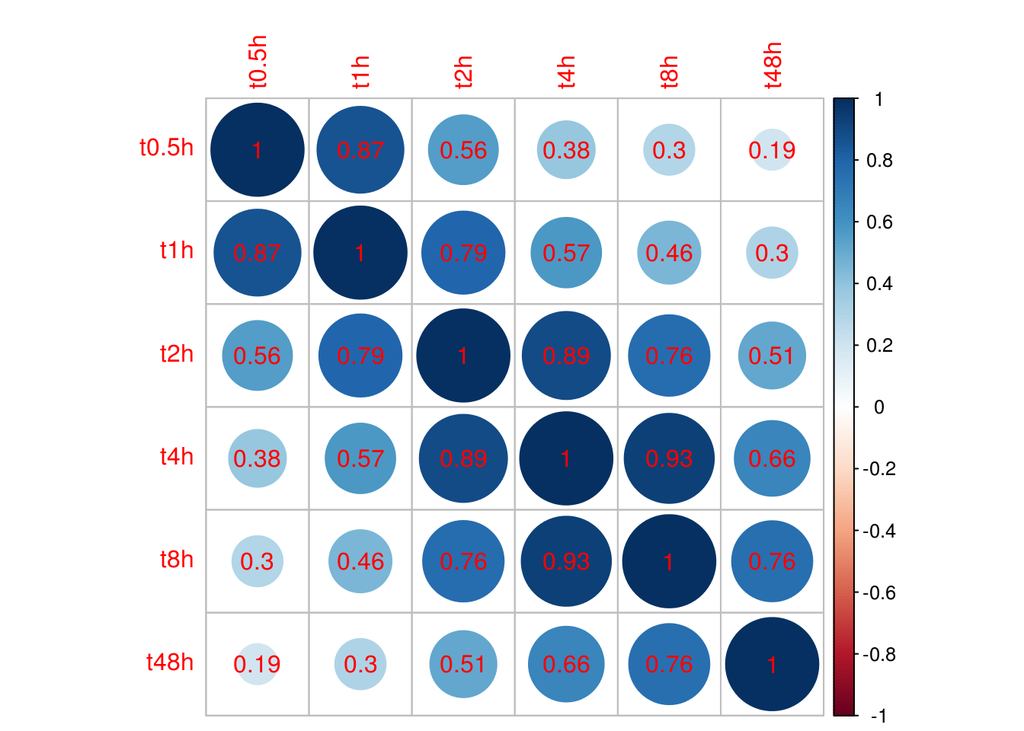

```r
install.packages("corrplot", repos='http://cran.us.r-project.org')
library(corrplot)
#?corrplot
corrplot(corr=cor(Adip.exp.DEGs, use="na.or.complete"), addCoef.col="red")
```

### Practice 2

Cluster evaluation R package (clueR) is a package to determine optimal fuzzy k-mean clustering from time-series data. Please following the steps below to analyse and visualise the time-series data from Adipogenesis:

**Step 1:** Install an R package called ‘clueR’ from CRAN.

```r
install.packages("ClueR", repos='http://cran.us.r-project.org')
```

```r
library(ClueR)
data(Pathways)
rownames(Adip.exp.DEGs) <- toupper(rownames(Adip.exp.DEGs))
clueObj <- runClue(Tc=Adip.exp.DEGs, annotation=Pathways.KEGG, rep = 5, kRange=20)
```

```
## repeat 1
## repeat 2
## repeat 3
## repeat 4
## repeat 5
```

**Step 3:** clueObj is a list that contains various evaluation information and statistics. clueObj$evlMat is the evaluation matrix that contains the clustering goodness from k=2 to k=20. Calculate means and standard deviations with respect to each column of this matrix.

**Step 4:** Install an R package called ‘Hmisc’, plot means calculated in step 3, and add standard deviations as error bar using function ‘errbar’ from ‘Hmisc’.

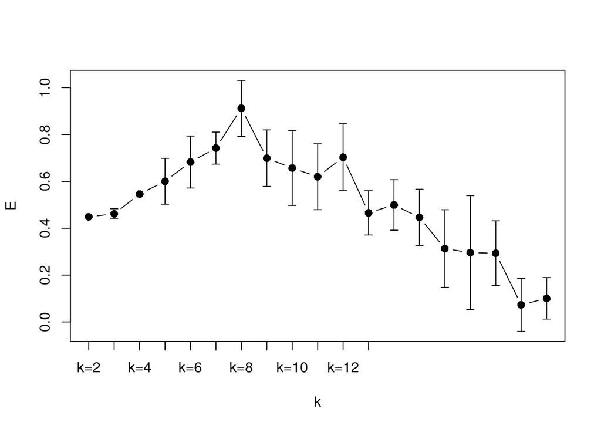

```r
Ms <- apply(clueObj$evlMat, 2, mean, na.rm=TRUE)
Ss <- apply(clueObj$evlMat, 2, sd, na.rm=TRUE)
library(Hmisc)
errbar(1:length(Ms), Ms, Ms+Ss, Ms-Ss, cex=1.2, type="b", xaxt="n", xlab="k", ylab="E")
axis(1, at=1:12, labels=paste("k=", 2:13, sep=""))
```

**Step 5:** Run the following code to obtain optimal clustering result determined by clueR

```r
# generate the optimal clustering results
 best <- clustOptimal(clueObj, rep=10, mfrow=c(4, 4))
# list enriched clusters
 best$enrichList
```

```
## $`cluster 1`
##      kinase                                      pvalue
## [1,] "KEGG_LEUKOCYTE_TRANSENDOTHELIAL_MIGRATION" "0.000860504635414487"
## [2,] "KEGG_ECM_RECEPTOR_INTERACTION"             "0.00229174250990328"
## [3,] "KEGG_FOCAL_ADHESION"                       "0.00340351817349834"
## [4,] "KEGG_CELL_ADHESION_MOLECULES_CAMS"         "0.00406164663418142"
## [5,] "KEGG_TGF_BETA_SIGNALING_PATHWAY"           "0.00517287333818962"
##      size substrates
## [1,] "5"  "MYL9|JAM2|VCAM1|MMP9|ACTN3"
## [2,] "7"  "THBS1|THBS2|SDC3|COL1A1|THBS3|ITGA8|COL1A2"
## [3,] "9"  "JUN|MYL9|THBS1|THBS2|ACTN3|COL1A1|THBS3|ITGA8|COL1A2"
## [4,] "5"  "JAM2|SDC3|VCAM1|NCAM1|ITGA8"
## [5,] "6"  "ID1|SMAD7|THBS1|THBS2|ID2|THBS3"
##
## $`cluster 3`
##      kinase                                      pvalue
## [1,] "KEGG_PATHWAYS_IN_CANCER"                   "0.00327856114905081"
## [2,] "KEGG_TOLL_LIKE_RECEPTOR_SIGNALING_PATHWAY" "0.00752491401707902"
##      size substrates
## [1,] "10" "FOS|IL6|BMP4|RUNX1T1|FZD2|PML|FAS|JUP|VEGFC|BCL2"
## [2,] "5"  "FOS|IL6|TLR3|MAP2K6|TLR6"
##
## $`cluster 4`
##      kinase            pvalue                size
## [1,] "KEGG_PEROXISOME" "0.00648851230995222" "5"
##      substrates
## [1,] "HACL1|ABCD2|IDH1|DECR2|PHYH"
##
## $`cluster 5`
##      kinase                       pvalue                 size
## [1,] "KEGG_PURINE_METABOLISM"     "6.65351168891175e-05" "9"
## [2,] "KEGG_PYRIMIDINE_METABOLISM" "0.000583607261829854" "5"
##      substrates
## [1,] "XDH|GDA|POLR1B|PPAT|POLR1E|POLR3G|PDE10A|ENTPD6|AK2"
## [2,] "POLR1B|POLR1E|CTPS|POLR3G|ENTPD6"
##
## $`cluster 6`
##      kinase                        pvalue                 size
## [1,] "KEGG_PPAR_SIGNALING_PATHWAY" "0.000274084656961875" "6"
##      substrates
## [1,] "ACSL1|FABP5|HMGCS2|SCP2|ANGPTL4|FABP4"
##
## $`cluster 7`
##      kinase
## [1,] "KEGG_DILATED_CARDIOMYOPATHY"
## [2,] "KEGG_HYPERTROPHIC_CARDIOMYOPATHY_HCM"
## [3,] "KEGG_ARRHYTHMOGENIC_RIGHT_VENTRICULAR_CARDIOMYOPATHY_ARVC"
##      pvalue                 size
## [1,] "6.87429311318869e-06" "9"
## [2,] "1.93370099629037e-05" "9"
## [3,] "0.0026996182623945"   "7"
##      substrates
## [1,] "SLC8A1|ITGB5|TPM1|ITGA11|ITGA1|SGCD|TGFB3|CACNG7|CACNB3"
## [2,] "SLC8A1|ITGB5|TPM1|ITGA11|ITGA1|SGCD|TGFB3|CACNG7|CACNB3"
## [3,] "SLC8A1|ITGB5|ITGA11|ITGA1|SGCD|CACNG7|CACNB3"
```

[figure not shown]